# persistent_homology(): which features are real

honets

2026-08-26

## The analytic question

`betti_numbers()` counts holes at **one** threshold, and the count is unstable: change the threshold slightly and loops appear and vanish. Any single-threshold result is partly an artefact of the choice.

`persistent_homology()` removes the choice. It sweeps the threshold across the whole range, tracks every feature from the scale where it is **born** to the scale where it **dies**, and reports how long each survived. Features that persist across many scales are structural; features that flicker in and out at one scale are noise.

This turns “how many holes?” — which has no threshold-free answer — into “which holes are robust?”, which does.

```r
library(honets)
set.seed(1)
m <- matrix(runif(100), 10, 10)
m <- (m + t(m)) / 2
diag(m) <- 0
dimnames(m) <- list(LETTERS[1:10], LETTERS[1:10])
```

## Running it

```r
ph <- persistent_homology(m, n_steps = 12, max_dim = 2)
ph
```

```
Persistent Homology
  12 filtration steps [0.9288 → 0.0093]
  Features: b0: 9 (1 persistent)  |  b1: 4 (0 persistent)  |  b2: 84 (84 persistent)
  Longest-lived:
    b0: 0.9288 → 0.0000 (life: 0.9288)
    b2: 0.5113 → 0.0000 (life: 0.5113)
    b2: 0.5113 → 0.0000 (life: 0.5113)
```

## The persistence diagram

One row per feature: the dimension it lives in, where it was born, where it died, and the difference.

```r
as.data.frame(ph, sort_by = "persistence", top = 8)
```

```
  dimension     birth death persistence
1         0 0.9287756     0   0.9287756
2         2 0.5113141     0   0.5113141
3         2 0.5113141     0   0.5113141
4         2 0.4918348     0   0.4918348
5         2 0.4770873     0   0.4770873
6         2 0.4770873     0   0.4770873
7         2 0.4767907     0   0.4767907
8         2 0.4767907     0   0.4767907
```

Note that `birth` exceeds `death` here. The filtration runs from a high weight threshold down to a low one, so features are born at high weights and die as the complex fills in. Persistence is the length of the interval either way.

## Reading one dimension at a time

```r
as.data.frame(ph, dimension = 1, sort_by = "persistence", top = 5)
```

```
  dimension     birth     death persistence
1         1 0.6902048 0.4918348   0.1983700
2         1 0.6880047 0.4999354   0.1880693
3         1 0.6853510 0.5633173   0.1220338
4         1 0.6348426 0.5245315   0.1103111
```

```r
as.data.frame(ph, dimension = 0, sort_by = "persistence", top = 5)
```

```
  dimension     birth     death persistence
1         0 0.9287756 0.0000000   0.9287756
2         0 0.9287756 0.6951440   0.2336316
3         0 0.9287756 0.7054163   0.2233593
4         0 0.9287756 0.7084508   0.2203248
5         0 0.9287756 0.7358231   0.1929525
```

Dimension 0 is the merge history of connected components — each row is two pieces joining. Dimension 1 is loops, dimension 2 voids.

## Betti curves

The same information viewed as counts against threshold, rather than as intervals.

```r
as.data.frame(ph, what = "betti", top = 8)
```

```
  threshold dimension betti
1 0.9287756         0     9
2 0.8451858         0     8
3 0.7615960         0     7
4 0.6780062         0     1
5 0.5944164         0     1
6 0.5108266         0     1
7 0.4272368         0     1
8 0.3436470         0     1
```

Read the `b0` column down: **9 components at the highest threshold, then 8, 7, and then 1** — the graph rapidly coalesces into a single piece as the threshold falls. That transition point is where the network “connects”, and it is visible here without having to pick a threshold in advance.

## Plotting

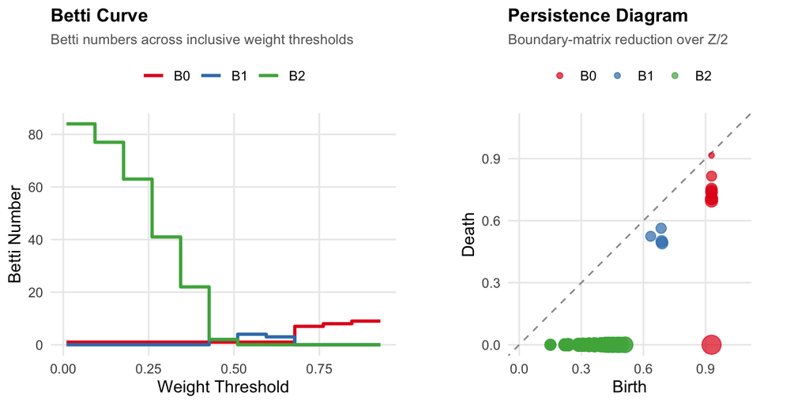

```r
if (requireNamespace("gridExtra", quietly = TRUE)) plot(ph)
```

The diagram plots death against birth; points far from the diagonal are the persistent features. The Betti curves show the counts across the sweep.

## Choosing `n_steps` and `max_dim`

```r
do.call(rbind, lapply(c(6L, 12L, 24L), function(ns) {
  p <- persistent_homology(m, n_steps = ns, max_dim = 2)
  d <- as.data.frame(p)
  data.frame(n_steps = ns, features = nrow(d),
             max_persistence = round(max(d$persistence), 4))
}))
```

```
  n_steps features max_persistence
1       6       97          0.9288
2      12       97          0.9288
3      24       97          0.9288
```

`n_steps` controls the resolution of the sweep — more steps locate births and deaths more precisely, at linear cost. The **longest-lived feature is stable across resolutions**, which is the reassurance you want: the headline finding does not depend on the grid.

`max_dim` is the expensive one. It defaults to `3L` here (rather than the `10L` that `build_simplicial()` uses) precisely because complexes grow combinatorially with dimension. Raise it only if you have a reason to expect structure above dimension 3.

## Essential classes

```r
d <- as.data.frame(ph)
sum(!is.finite(d$death))
```

```
[1] 0
```

Features that never die are reported with `death = Inf`. There are none in this filtration because it runs to completion. When comparing diagrams with `bottleneck_distance()`, essential classes need explicit handling — the reference implementations differ on whether to include them.

## Validation

The Z/2 boundary-matrix reduction behind this verb is checked against **ripser** (via `TDAstats`) in the package’s equivalence suite: 30 random point clouds, maximum discrepancy 4.44e-16 — machine precision.

## What to do next

- **`persistence_landscape()`** — turn a diagram into something you can average, plot and compare statistically.
- **`betti_numbers()`** — the single-threshold version, and why it needs a sweep.
- **`build_simplicial()`** — the complexes this filters over.

## References

- Edelsbrunner, H., Letscher, D., & Zomorodian, A. (2002). Topological persistence and simplification. *Discrete & Computational Geometry*, 28, 511-533.
- Zomorodian, A., & Carlsson, G. (2005). Computing persistent homology. *Discrete & Computational Geometry*, 33(2), 249-274.
- Ghrist, R. (2008). Barcodes: The persistent topology of data. *Bulletin of the American Mathematical Society*, 45(1), 61-75.